# Good Data Practices with R and RStudio

EC 325: Econometrics

Prof. Caraher

Colby College

2026-02-11

# Good Data Practices

## When Good Economists Use Bad Data

- What is the role of the government in times of economic crisis?
- Question received renewed interest in 2008-2009 financial crisis

## When Good Economists Use Bad Data

- In 2010, economists Reinhart and Rogoff published influential research on government debt and economic growth.
- **Key finding:** When a country’s debt exceeds 90% of GDP, economic growth drops *dramatically* and becomes negative.

## When Good Economists Use Bad Data

- This strongly influenced policy debates worldwide during the Great Recession.
- It suggested a policy of *austerity*–cutting government expenditures during an economic crisis–was the correct policy
- Went against more established, *Keynesian* policies

## Reinhart-Rogoff Results

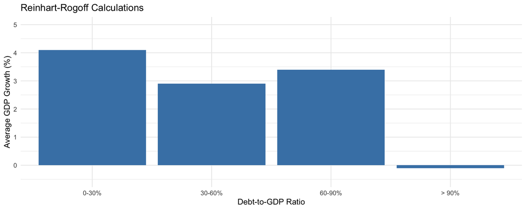

## When Good Economists Use Bad Data

- However, there was a problem…
- In 2014, graduate student Thomas Herndon tried to replicate the results for a homework assignment.

He discovered three issues:

- Some observations were mistakenly excluded
- Observations were weighed strangely
- **Excel spreadsheet errors** — some cells weren’t included in calculations!

## Corrected Results (Herndon, Ash, Pollin)

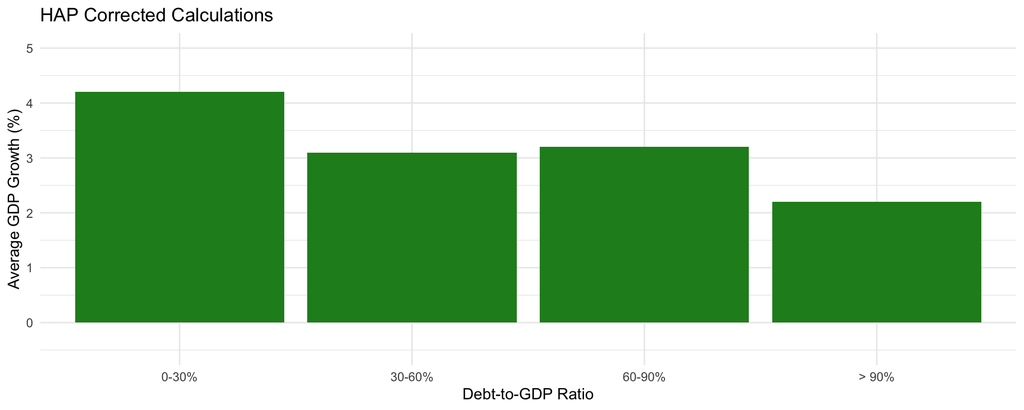

## When Good Economists Use Bad Data

When the data were corrected:

- The dramatic “cliff” in economic growth **disappeared**
- The relationship was much more gradual
- The policy story was **very different**

**The Lesson**

Good data practices are fundamental to credible research. No sophisticated technique can compensate for errors in the underlying data.

## Good Data Practices

- It is **essential** to first get to know your data before you do any analysis

Some questions to ask:

- How many observations? What is missing?
- What is the distribution like? Does it make sense?
- Are there any outliers?

## Good Data Practices

- A few good ways to get to know your data:
1. Descriptive statistics
   - **N:** number of observations — any missing?
   - **Mean:** Average values — is it reasonable?
   - **Min/Max:** Range — any impossible values?
2. Visualizations
   - Can also help identify similar issues
   - Bar graphs, scatterplots, etc.

## Spotting Problems: An Example

- Suppose we’re studying education and wages.
- The raw data might look something like this:

| id | education | wage | age |
| --- | --- | --- | --- |
| 1 | 18 | 56 | 30 |
| 2 | 18 | 38 | 20 |
| 3 | 10 | 62 | 59 |
| 4 | 14 | 180 | 45 |
| 5 | 19 | 135 | 27 |

- It’s hard to tell if something is wrong by staring at a list of numbers…

## Spotting Problems: An Example

- So let’s look at some *descriptive statistics* to help:

[output not shown]

**Red Flags:**

- Education = -5 years is **impossible**
- Wage = $850/hr seems **suspiciously high**
- Age = 200 is clearly a **data entry error**

# Getting to Know R

## Starting to work with RStudio

- Before we get into using descriptive statistics to learn about data, let’s first get used to R a little!
- Hopefully, you have already installed R, RStudio, and Git
- Go ahead and open RStudio

## The RStudio Interface

You should see four main panels:

| Panel | Purpose |
| --- | --- |
| **Script Editor** | Write and save your R code |
| **Console** | Execute code, see output |
| **Environment** | View your stored objects |
| **Plots/Help** | View visualizations & documentation |

- For now, **let’s just focus on the console**

## How to Follow Along

Throughout these slides, look for this marker:

**🖥️ Try it yourself!**

Type along in your console as we go

## Basic R Operations

**🖥️ Try it yourself!**

- R can work as a calculator!
- Type each expression below in your console:

```r
4 + 2
```

```
[1] 6
```

```r
4.65 * 9.3
```

```
[1] 43.245
```

```r
(8 + 2.9) * (654 / 98)
```

```
[1] 72.74082
```

## Objects and Assignment

- As an **Object-Orientated Language,** the logic of R is built around interacting with **objects**
- An object is a generic name for anything that is “saved” in R
- This includes numbers, vectors, functions, or essentially anything else we will interact with or have to reference

## Objects and Assignment

**🖥️ Try it yourself!**

- Store things as an object using the assignment operator `<-`
- Try typing these in your console:

```r
x <- 3
x
```

```
[1] 3
```

```r
y <- 5
y
```

```
[1] 5
```

```r
x + y
```

```
[1] 8
```

## Vectors

**🖥️ Try it yourself!**

- A vector is a sequence of values of the same type
- Use the `c()` function to **combine** values into a vector
- Operations apply to each element:

```r
ages <- c(19, 20, 21, 22, 20, 19)
ages
```

```
[1] 19 20 21 22 20 19
```

```r
ages + 10
```

```
[1] 29 30 31 32 30 29
```

```r
primes <- c(1, 3, 5, 7, 9, 11)

ages + primes
```

```
[1] 20 23 26 29 29 30
```

## Functions

**🖥️ Try it yourself!**

- Functions are pre-packaged sets of instructions that perform specific tasks
- Every function requires an *argument* to produce output
- Try the `seq()` function, which generates a sequence of numbers:

```r
bb <- seq(from = 1, to = 30, by = 3)
bb
```

```
 [1]  1  4  7 10 13 16 19 22 25 28
```

- `from`, `to`, and `by` are the arguments of the function
- We set `from = 1` to start at 1, `to = 30` to end at 30, and `by = 3` to increment by 3
- Every functions has a different set of arguments
- We can look up documentation on how to use a function using the `?` function

## Data Frames

- A data frame is the main way datasets are stored as objects
- Basically resembles a spreadsheet: rows = observations, columns = variables
- The `head()` function prints only the first `n` rows:

```r
head(mtcars, 4)
```

```
                mpg cyl disp  hp drat    wt  qsec vs am gear carb
Mazda RX4      21.0   6  160 110 3.90 2.620 16.46  0  1    4    4
Mazda RX4 Wag  21.0   6  160 110 3.90 2.875 17.02  0  1    4    4
Datsun 710     22.8   4  108  93 3.85 2.320 18.61  1  1    4    1
Hornet 4 Drive 21.4   6  258 110 3.08 3.215 19.44  1  0    3    1
```

- We can pull a specific column with `$` (useful for many functions)

```r
head(mtcars$mpg, 10)
```

```
 [1] 21.0 21.0 22.8 21.4 18.7 18.1 14.3 24.4 22.8 19.2
```

## Data Types

- Every piece of data in R has a type that determines how it can be used
- The main types are numeric (numbers), character (text), logical (true/false), and factor(categories)
- Depending on the datatype, functions will operate differently or not at all

## Data Types

```r
# Numeric: numbers for calculations
age <- 25
price <- 19.99
temperature <- -5.2

# Math works naturally
age * price
```

```
[1] 499.75
```

```r
price * 1.08
```

```
[1] 21.5892
```

```r
# Character: text strings (always in quotes)
name <- "Boston"
greeting <- 'Hello World'

# But can combine them
paste("Hello", name)  # "Hello Boston"
```

```
[1] "Hello Boston"
```

```r
# Can't do math on characters!
greeting + "3"  # Error!
```

## R Packages

- R’s real power comes from **packages** — collections of functions written by others
- Think of them as “add-ons” that extend what R can do

**Two-step process:**

1. Install the package (only do it once!)
2. Load the package using `library()` (every time!)

```r
# Step 1: Install ONCE (like downloading an app)
install.packages("tidyverse")

# Step 2: Load EVERY session (like opening the app)
library(tidyverse)
```

# Data Manipulation in R

## What is the `tidyverse`?

- We will work with the suite of `tidyverse` functions to do data manipulation and exploration
- The `tidyverse` is a collection of R packages designed for data science.
- These packages share a common philosophy and work seamlessly together

Includes:

- `dplyr`: the engine for data cleaning and manipulation
- `ggplot2`: the engine for data visualization
- `readr`: the engine for reading a diverse set of data files

We will work with all of these engines.

## The `mtcars` data

- Let’s learn about `tidyverse` functions using the `mtcars` data

```r
mtcars
```

```
                     mpg cyl  disp  hp drat    wt  qsec vs am gear carb
Mazda RX4           21.0   6 160.0 110 3.90 2.620 16.46  0  1    4    4
Mazda RX4 Wag       21.0   6 160.0 110 3.90 2.875 17.02  0  1    4    4
Datsun 710          22.8   4 108.0  93 3.85 2.320 18.61  1  1    4    1
Hornet 4 Drive      21.4   6 258.0 110 3.08 3.215 19.44  1  0    3    1
Hornet Sportabout   18.7   8 360.0 175 3.15 3.440 17.02  0  0    3    2
Valiant             18.1   6 225.0 105 2.76 3.460 20.22  1  0    3    1
Duster 360          14.3   8 360.0 245 3.21 3.570 15.84  0  0    3    4
Merc 240D           24.4   4 146.7  62 3.69 3.190 20.00  1  0    4    2
Merc 230            22.8   4 140.8  95 3.92 3.150 22.90  1  0    4    2
Merc 280            19.2   6 167.6 123 3.92 3.440 18.30  1  0    4    4
Merc 280C           17.8   6 167.6 123 3.92 3.440 18.90  1  0    4    4
Merc 450SE          16.4   8 275.8 180 3.07 4.070 17.40  0  0    3    3
Merc 450SL          17.3   8 275.8 180 3.07 3.730 17.60  0  0    3    3
Merc 450SLC         15.2   8 275.8 180 3.07 3.780 18.00  0  0    3    3
Cadillac Fleetwood  10.4   8 472.0 205 2.93 5.250 17.98  0  0    3    4
Lincoln Continental 10.4   8 460.0 215 3.00 5.424 17.82  0  0    3    4
Chrysler Imperial   14.7   8 440.0 230 3.23 5.345 17.42  0  0    3    4
Fiat 128            32.4   4  78.7  66 4.08 2.200 19.47  1  1    4    1
Honda Civic         30.4   4  75.7  52 4.93 1.615 18.52  1  1    4    2
Toyota Corolla      33.9   4  71.1  65 4.22 1.835 19.90  1  1    4    1
Toyota Corona       21.5   4 120.1  97 3.70 2.465 20.01  1  0    3    1
Dodge Challenger    15.5   8 318.0 150 2.76 3.520 16.87  0  0    3    2
AMC Javelin         15.2   8 304.0 150 3.15 3.435 17.30  0  0    3    2
Camaro Z28          13.3   8 350.0 245 3.73 3.840 15.41  0  0    3    4
Pontiac Firebird    19.2   8 400.0 175 3.08 3.845 17.05  0  0    3    2
Fiat X1-9           27.3   4  79.0  66 4.08 1.935 18.90  1  1    4    1
Porsche 914-2       26.0   4 120.3  91 4.43 2.140 16.70  0  1    5    2
Lotus Europa        30.4   4  95.1 113 3.77 1.513 16.90  1  1    5    2
Ford Pantera L      15.8   8 351.0 264 4.22 3.170 14.50  0  1    5    4
Ferrari Dino        19.7   6 145.0 175 3.62 2.770 15.50  0  1    5    6
Maserati Bora       15.0   8 301.0 335 3.54 3.570 14.60  0  1    5    8
Volvo 142E          21.4   4 121.0 109 4.11 2.780 18.60  1  1    4    2
```

## The Pipe `|>`

- Takes whatever is to the left of `|>` and passes it as the first argument to the function to the right of `|>`
- Kind of like “and then” in a sentence

```r
# Take mtcars AND THEN filter to high-mpg cars
mtcars |>
  filter(mpg > 25)
```

```
                mpg cyl  disp  hp drat    wt  qsec vs am gear carb
Fiat 128       32.4   4  78.7  66 4.08 2.200 19.47  1  1    4    1
Honda Civic    30.4   4  75.7  52 4.93 1.615 18.52  1  1    4    2
Toyota Corolla 33.9   4  71.1  65 4.22 1.835 19.90  1  1    4    1
Fiat X1-9      27.3   4  79.0  66 4.08 1.935 18.90  1  1    4    1
Porsche 914-2  26.0   4 120.3  91 4.43 2.140 16.70  0  1    5    2
Lotus Europa   30.4   4  95.1 113 3.77 1.513 16.90  1  1    5    2
```

## Key Functions for Data Manipulation

- The `tidyverse` gives us a set of intuitive *verbs* for working with data
- Each function does **one thing** well
- They all follow the same pattern: first argument is the data, then the details

## `filter()`: Subset Rows

- **Purpose:** Keep only the rows that meet a condition

```r
mtcars |>
  filter(mpg > 25)
```

```
                mpg cyl  disp  hp drat    wt  qsec vs am gear carb
Fiat 128       32.4   4  78.7  66 4.08 2.200 19.47  1  1    4    1
Honda Civic    30.4   4  75.7  52 4.93 1.615 18.52  1  1    4    2
Toyota Corolla 33.9   4  71.1  65 4.22 1.835 19.90  1  1    4    1
Fiat X1-9      27.3   4  79.0  66 4.08 1.935 18.90  1  1    4    1
Porsche 914-2  26.0   4 120.3  91 4.43 2.140 16.70  0  1    5    2
Lotus Europa   30.4   4  95.1 113 3.77 1.513 16.90  1  1    5    2
```

## `select()`: Choose Columns

- **Purpose:** Keep (or drop) specific columns from a data frame

```r
mtcars |>
  select(mpg, cyl, wt)
```

```
                     mpg cyl    wt
Mazda RX4           21.0   6 2.620
Mazda RX4 Wag       21.0   6 2.875
Datsun 710          22.8   4 2.320
Hornet 4 Drive      21.4   6 3.215
Hornet Sportabout   18.7   8 3.440
Valiant             18.1   6 3.460
Duster 360          14.3   8 3.570
Merc 240D           24.4   4 3.190
Merc 230            22.8   4 3.150
Merc 280            19.2   6 3.440
Merc 280C           17.8   6 3.440
Merc 450SE          16.4   8 4.070
Merc 450SL          17.3   8 3.730
Merc 450SLC         15.2   8 3.780
Cadillac Fleetwood  10.4   8 5.250
Lincoln Continental 10.4   8 5.424
Chrysler Imperial   14.7   8 5.345
Fiat 128            32.4   4 2.200
Honda Civic         30.4   4 1.615
Toyota Corolla      33.9   4 1.835
Toyota Corona       21.5   4 2.465
Dodge Challenger    15.5   8 3.520
AMC Javelin         15.2   8 3.435
Camaro Z28          13.3   8 3.840
Pontiac Firebird    19.2   8 3.845
Fiat X1-9           27.3   4 1.935
Porsche 914-2       26.0   4 2.140
Lotus Europa        30.4   4 1.513
Ford Pantera L      15.8   8 3.170
Ferrari Dino        19.7   6 2.770
Maserati Bora       15.0   8 3.570
Volvo 142E          21.4   4 2.780
```

## `mutate()`: Create New Variables

- **Purpose:** Add new columns or modify existing ones

```r
mtcars |>
  mutate(kmpl = mpg * 0.425)
```

```
                     mpg cyl  disp  hp drat    wt  qsec vs am gear carb    kmpl
Mazda RX4           21.0   6 160.0 110 3.90 2.620 16.46  0  1    4    4  8.9250
Mazda RX4 Wag       21.0   6 160.0 110 3.90 2.875 17.02  0  1    4    4  8.9250
Datsun 710          22.8   4 108.0  93 3.85 2.320 18.61  1  1    4    1  9.6900
Hornet 4 Drive      21.4   6 258.0 110 3.08 3.215 19.44  1  0    3    1  9.0950
Hornet Sportabout   18.7   8 360.0 175 3.15 3.440 17.02  0  0    3    2  7.9475
Valiant             18.1   6 225.0 105 2.76 3.460 20.22  1  0    3    1  7.6925
Duster 360          14.3   8 360.0 245 3.21 3.570 15.84  0  0    3    4  6.0775
Merc 240D           24.4   4 146.7  62 3.69 3.190 20.00  1  0    4    2 10.3700
Merc 230            22.8   4 140.8  95 3.92 3.150 22.90  1  0    4    2  9.6900
Merc 280            19.2   6 167.6 123 3.92 3.440 18.30  1  0    4    4  8.1600
Merc 280C           17.8   6 167.6 123 3.92 3.440 18.90  1  0    4    4  7.5650
Merc 450SE          16.4   8 275.8 180 3.07 4.070 17.40  0  0    3    3  6.9700
Merc 450SL          17.3   8 275.8 180 3.07 3.730 17.60  0  0    3    3  7.3525
Merc 450SLC         15.2   8 275.8 180 3.07 3.780 18.00  0  0    3    3  6.4600
Cadillac Fleetwood  10.4   8 472.0 205 2.93 5.250 17.98  0  0    3    4  4.4200
Lincoln Continental 10.4   8 460.0 215 3.00 5.424 17.82  0  0    3    4  4.4200
Chrysler Imperial   14.7   8 440.0 230 3.23 5.345 17.42  0  0    3    4  6.2475
Fiat 128            32.4   4  78.7  66 4.08 2.200 19.47  1  1    4    1 13.7700
Honda Civic         30.4   4  75.7  52 4.93 1.615 18.52  1  1    4    2 12.9200
Toyota Corolla      33.9   4  71.1  65 4.22 1.835 19.90  1  1    4    1 14.4075
Toyota Corona       21.5   4 120.1  97 3.70 2.465 20.01  1  0    3    1  9.1375
Dodge Challenger    15.5   8 318.0 150 2.76 3.520 16.87  0  0    3    2  6.5875
AMC Javelin         15.2   8 304.0 150 3.15 3.435 17.30  0  0    3    2  6.4600
Camaro Z28          13.3   8 350.0 245 3.73 3.840 15.41  0  0    3    4  5.6525
Pontiac Firebird    19.2   8 400.0 175 3.08 3.845 17.05  0  0    3    2  8.1600
Fiat X1-9           27.3   4  79.0  66 4.08 1.935 18.90  1  1    4    1 11.6025
Porsche 914-2       26.0   4 120.3  91 4.43 2.140 16.70  0  1    5    2 11.0500
Lotus Europa        30.4   4  95.1 113 3.77 1.513 16.90  1  1    5    2 12.9200
Ford Pantera L      15.8   8 351.0 264 4.22 3.170 14.50  0  1    5    4  6.7150
Ferrari Dino        19.7   6 145.0 175 3.62 2.770 15.50  0  1    5    6  8.3725
Maserati Bora       15.0   8 301.0 335 3.54 3.570 14.60  0  1    5    8  6.3750
Volvo 142E          21.4   4 121.0 109 4.11 2.780 18.60  1  1    4    2  9.0950
```

## Chaining Multiple Verbs Together

- The real power of the pipe: **chain multiple operations** in sequence
- Read it like a sentence: “Take the data, *then* filter, *then* mutate, *then* select…”

```r
mtcars |>
  filter(cyl == 4) |>
  mutate(kmpl = mpg * 0.425) |>
  select(mpg, kmpl, wt)
```

```
                mpg    kmpl    wt
Datsun 710     22.8  9.6900 2.320
Merc 240D      24.4 10.3700 3.190
Merc 230       22.8  9.6900 3.150
Fiat 128       32.4 13.7700 2.200
Honda Civic    30.4 12.9200 1.615
Toyota Corolla 33.9 14.4075 1.835
Toyota Corona  21.5  9.1375 2.465
Fiat X1-9      27.3 11.6025 1.935
Porsche 914-2  26.0 11.0500 2.140
Lotus Europa   30.4 12.9200 1.513
Volvo 142E     21.4  9.0950 2.780
```

## Saving Your Work as a New Object

- So far, we’ve just been **printing** results to the console
- To keep the manipulated data, **save it as a new object** using `<-`

```r
# Create a new dataset with only efficient 4-cylinder cars
efficient_cars <- mtcars |>
  filter(cyl == 4, mpg > 25) |>
  select(mpg, hp, wt)

efficient_cars
```

```
                mpg  hp    wt
Fiat 128       32.4  66 2.200
Honda Civic    30.4  52 1.615
Toyota Corolla 33.9  65 1.835
Fiat X1-9      27.3  66 1.935
Porsche 914-2  26.0  91 2.140
Lotus Europa   30.4 113 1.513
```

- Now `efficient_cars` is stored in your environment and can be used later!

# Descriptive Statistics in R

## Remember: Know Your Data

Before any analysis, we need to answer three key questions:

1. **Are there errors?** Is the distribution reasonable?
   - Use descriptive stats: `mean()`, `min()`, `max()`, `summarize()`
2. **Is there missing data?** How much?
   - Use `is.na()`, `sum(is.na())`
3. **Are there outliers or patterns?**
   - Use visualizations: histograms, scatterplots

Let’s learn the tools to answer these questions!

## Descriptive Statistics Functions

- R has built-in functions for computing common descriptive statistics
- These operate on **vectors** (i.e., columns of a data frame; reference them using `$`)

| Function | What it computes |
| --- | --- |
| `mean()` | Average |
| `sd()` | Standard deviation |
| `median()` | Median (middle value) |
| `min()` / `max()` | Minimum / Maximum |
| `n()` | Number of observations |

## Descriptive Statistics Functions

```r
mean(mtcars$mpg)
```

```
[1] 20.09062
```

```r
sd(mtcars$mpg)
```

```
[1] 6.026948
```

```r
min(mtcars$mpg)
```

```
[1] 10.4
```

- These are useful on their own, but become **much more powerful** inside `summarize()`

## Handling Missing Data

- Before computing statistics, check for **missing values** (`NA`)
- Many R functions return `NA` if any value is missing
- `is.na()` checks for missing values; `sum(is.na())` counts them
- The `airquality` dataset (built into R) has some missing values:

```r
sum(is.na(airquality$Ozone))
```

```
[1] 37
```

## Handling Missing Data

- If you try to compute the mean with missing values:

```r
mean(airquality$Ozone)
```

```
[1] NA
```

- Use `na.rm = TRUE` to ignore missing values:

```r
mean(airquality$Ozone, na.rm = TRUE)
```

```
[1] 42.12931
```

## What Do We Do About Missing Data?

- In this class, we will largely **ignore missing values** using `na.rm = TRUE` (or similar arguments depending on the function)
- This is fine when data are **missing at random**
- But be careful: sometimes data are **missing systematically**
- When this happens, ignoring missing values can lead to **biased results**

## Systematically Missing Data: Examples

When might data be missing in a non-random way?

- **Income surveys**: High earners may refuse to report income
  - Dropping them underestimates average income
- **Health studies**: Sicker patients may drop out of a study
  - Remaining sample looks healthier than it really is
- **Student evaluations**: Students who dropped the course don’t fill them out
  - Evaluations only reflect students who stayed

## Systematically Missing Data

- **Takeaway**: Always ask *why* data might be missing
- If missingness is related to the outcome you’re studying, simple fixes like `na.rm = TRUE` can give misleading results
- Advanced methods exist to handle this (multiple imputation, selection models)
- For now, just be aware of the issue!

## `summarize()`: Compute Summary Statistics

- **Purpose:** Collapse a data frame into a single summary row

```r
mtcars |>
  summarize(
    mean_mpg = mean(mpg),
    sd_mpg = sd(mpg),
    n = n()
  )
```

```
  mean_mpg   sd_mpg  n
1 20.09062 6.026948 32
```

## `group_by()` + `summarize()`: Grouped Summaries

- **Purpose:** Split data into groups and summarize each group separately
- Pair `group_by()` with `summarize()` to get statistics *by group*

```r
mtcars |>
  group_by(cyl) |>
  summarize(
    mean_mpg = mean(mpg),
    mean_hp = mean(hp),
    n = n()
  )
```

```
# A tibble: 3 × 4
    cyl mean_mpg mean_hp     n
  <dbl>    <dbl>   <dbl> <int>
1     4     26.7    82.6    11
2     6     19.7   122.      7
3     8     15.1   209.     14
```

- When computing descriptive statistics with `summarize()`, you don’t need to use `$`!

## Storing Summary Statistics as Objects

- It is sometimes useful to **save** your summary statistics as an object
- This lets you reference them later — for example, in a plot or a report

```r
mpg_by_cyl <- mtcars |>
  group_by(cyl) |>
  summarize(
    mean_mpg = mean(mpg),
    sd_mpg = sd(mpg)
  )

mpg_by_cyl
```

```
# A tibble: 3 × 3
    cyl mean_mpg sd_mpg
  <dbl>    <dbl>  <dbl>
1     4     26.7   4.51
2     6     19.7   1.45
3     8     15.1   2.56
```

- Now `mpg_by_cyl` is stored in your environment and can be used just like any other data frame

## `count()`: See Unique Values

- **Purpose:** Quickly count the number of rows for each unique value of a variable
- A shortcut for `group_by() |> summarize(n = n())`
- Great for getting a feel for categorical variables in your data

```r
mtcars |>
  count(cyl)
```

```
  cyl  n
1   4 11
2   6  7
3   8 14
```

- You can also count combinations of variables:

```r
mtcars |>
  count(cyl, am)
```

```
  cyl am  n
1   4  0  3
2   4  1  8
3   6  0  4
4   6  1  3
5   8  0 12
6   8  1  2
```

## `arrange()`: Sort Rows

- **Purpose:** Reorder rows based on one or more columns
- **Key arguments:**
  - `...`: columns to sort by (use `desc()` for descending order)

```r
mtcars |>
  arrange(desc(mpg)) |>
  select(mpg, cyl, hp)
```

```
                     mpg cyl  hp
Toyota Corolla      33.9   4  65
Fiat 128            32.4   4  66
Honda Civic         30.4   4  52
Lotus Europa        30.4   4 113
Fiat X1-9           27.3   4  66
Porsche 914-2       26.0   4  91
Merc 240D           24.4   4  62
Datsun 710          22.8   4  93
Merc 230            22.8   4  95
Toyota Corona       21.5   4  97
Hornet 4 Drive      21.4   6 110
Volvo 142E          21.4   4 109
Mazda RX4           21.0   6 110
Mazda RX4 Wag       21.0   6 110
Ferrari Dino        19.7   6 175
Merc 280            19.2   6 123
Pontiac Firebird    19.2   8 175
Hornet Sportabout   18.7   8 175
Valiant             18.1   6 105
Merc 280C           17.8   6 123
Merc 450SL          17.3   8 180
Merc 450SE          16.4   8 180
Ford Pantera L      15.8   8 264
Dodge Challenger    15.5   8 150
Merc 450SLC         15.2   8 180
AMC Javelin         15.2   8 150
Maserati Bora       15.0   8 335
Chrysler Imperial   14.7   8 230
Duster 360          14.3   8 245
Camaro Z28          13.3   8 245
Cadillac Fleetwood  10.4   8 205
Lincoln Continental 10.4   8 215
```

## Quick Summary Tools

- Writing out each statistic with `summarize()` gives you full control, but sometimes you just want a **quick overview**
- R has some handy built-in functions for this

**`summary()`** — gives you min, quartiles, mean, and max for every column:

```r
summary(mtcars)
```

```
      mpg             cyl             disp             hp
 Min.   :10.40   Min.   :4.000   Min.   : 71.1   Min.   : 52.0
 1st Qu.:15.43   1st Qu.:4.000   1st Qu.:120.8   1st Qu.: 96.5
 Median :19.20   Median :6.000   Median :196.3   Median :123.0
 Mean   :20.09   Mean   :6.188   Mean   :230.7   Mean   :146.7
 3rd Qu.:22.80   3rd Qu.:8.000   3rd Qu.:326.0   3rd Qu.:180.0
 Max.   :33.90   Max.   :8.000   Max.   :472.0   Max.   :335.0
      drat             wt             qsec             vs
 Min.   :2.760   Min.   :1.513   Min.   :14.50   Min.   :0.0000
 1st Qu.:3.080   1st Qu.:2.581   1st Qu.:16.89   1st Qu.:0.0000
 Median :3.695   Median :3.325   Median :17.71   Median :0.0000
 Mean   :3.597   Mean   :3.217   Mean   :17.85   Mean   :0.4375
 3rd Qu.:3.920   3rd Qu.:3.610   3rd Qu.:18.90   3rd Qu.:1.0000
 Max.   :4.930   Max.   :5.424   Max.   :22.90   Max.   :1.0000
       am              gear            carb
 Min.   :0.0000   Min.   :3.000   Min.   :1.000
 1st Qu.:0.0000   1st Qu.:3.000   1st Qu.:2.000
 Median :0.0000   Median :4.000   Median :2.000
 Mean   :0.4062   Mean   :3.688   Mean   :2.812
 3rd Qu.:1.0000   3rd Qu.:4.000   3rd Qu.:4.000
 Max.   :1.0000   Max.   :5.000   Max.   :8.000
```

## Quick Summary Tools

**`glimpse()`** — shows the structure of your data (variable names, types, and first few values):

```r
glimpse(mtcars)
```

```
Rows: 32
Columns: 11
$ mpg  <dbl> 21.0, 21.0, 22.8, 21.4, 18.7, 18.1, 14.3, 24.4, 22.8, 19.2, 17.8,…
$ cyl  <dbl> 6, 6, 4, 6, 8, 6, 8, 4, 4, 6, 6, 8, 8, 8, 8, 8, 8, 4, 4, 4, 4, 8,…
$ disp <dbl> 160.0, 160.0, 108.0, 258.0, 360.0, 225.0, 360.0, 146.7, 140.8, 16…
$ hp   <dbl> 110, 110, 93, 110, 175, 105, 245, 62, 95, 123, 123, 180, 180, 180…
$ drat <dbl> 3.90, 3.90, 3.85, 3.08, 3.15, 2.76, 3.21, 3.69, 3.92, 3.92, 3.92,…
$ wt   <dbl> 2.620, 2.875, 2.320, 3.215, 3.440, 3.460, 3.570, 3.190, 3.150, 3.…
$ qsec <dbl> 16.46, 17.02, 18.61, 19.44, 17.02, 20.22, 15.84, 20.00, 22.90, 18…
$ vs   <dbl> 0, 0, 1, 1, 0, 1, 0, 1, 1, 1, 1, 0, 0, 0, 0, 0, 0, 1, 1, 1, 1, 0,…
$ am   <dbl> 1, 1, 1, 0, 0, 0, 0, 0, 0, 0, 0, 0, 0, 0, 0, 0, 0, 1, 1, 1, 0, 0,…
$ gear <dbl> 4, 4, 4, 3, 3, 3, 3, 4, 4, 4, 4, 3, 3, 3, 3, 3, 3, 4, 4, 4, 3, 3,…
$ carb <dbl> 4, 4, 1, 1, 2, 1, 4, 2, 2, 4, 4, 3, 3, 3, 4, 4, 4, 1, 2, 1, 1, 2,…
```

- `summary()` is great for spotting outliers and missing values at a glance
- `glimpse()` is great for checking variable types and making sure your data loaded correctly

## Practice: Try It Yourself!

**🖥️ Your turn!**

Using the `mtcars` data frame, answer each question using `tidyverse` functions. Try before clicking to reveal the answer!

## Practice 1

**What is the average horsepower (`hp`) of all cars in the dataset?**

- *Hint:* You only need `summarize()` and `mean()`

```r
mtcars |>
  summarize(mean_hp = mean(hp))
```

```
   mean_hp
1 146.6875
```

## Practice 2

**What is the average MPG for cars by the number of gears it has?

- *Hint:* First `group_by()` then `summarize()` and `mean()`

```r
mtcars |>
  group_by(gear) |>
  summarize(mean_mpg = mean(mpg))
```

```
# A tibble: 3 × 2
   gear mean_mpg
  <dbl>    <dbl>
1     3     16.1
2     4     24.5
3     5     21.4
```

## Practice 3

**Which car has the highest horsepower? Show only its `mpg`, `hp`, and `wt`.**

- *Hint:* `arrange()` in descending order using `desc()`, then `select()` and `head()`

```r
mtcars |>
  arrange(desc(hp)) |>
  select(mpg, hp, wt) |>
  head(1)
```

```
              mpg  hp   wt
Maserati Bora  15 335 3.57
```

## Practice 4

**Create a summary table showing the number of cars, mean weight (`wt`), and mean MPG for each number of cylinders (`cyl`).**

- *Hint:* `group_by()` + `summarize()` with `n()`, `mean(wt)`, and `mean(mpg)`

```r
mtcars |>
  group_by(cyl) |>
  summarize(
    n_cars = n(),
    mean_wt = mean(wt),
    mean_mpg = mean(mpg)
  )
```

```
# A tibble: 3 × 4
    cyl n_cars mean_wt mean_mpg
  <dbl>  <int>   <dbl>    <dbl>
1     4     11    2.29     26.7
2     6      7    3.12     19.7
3     8     14    4.00     15.1
```

## Practice 5

**Among cars that weigh less than 3,000 lbs (`wt < 3`), what is the mean and standard deviation of their quarter-mile time (`qsec`)?**

- *Hint:* `filter()` first, then `summarize()`

```r
mtcars |>
  filter(wt < 3) |>
  summarize(
    mean_qsec = mean(qsec),
    sd_qsec = sd(qsec),
    n = n()
  )
```

```
  mean_qsec sd_qsec  n
1  18.04917 1.47945 12
```

# Working with Scripts

## Why Use Scripts?

- So far, we’ve been typing directly into the **console**
- But the console doesn’t save your work!
- A **script** is a text file (`.R`) that contains your code
- You can save it, edit it, and run it again later
- Scripts are essential for **replication** — the foundation of credible research

## The Replication Standard

**Definition**

Research meets the **replication standard** when an independent researcher can exactly duplicate the results using only the information provided.

- Remember Reinhart-Rogoff: only because they shared their data and code could Thomas Herndon discover the errors
- Without replication materials, the mistakes might never have been found

## Why Replication Matters

1. **Allows others to check our work**
   - Errors happen — replication catches them
2. **Keeps our work honest**
   - If we know others will check, we’re more careful
3. **Helps our future selves**
   - What seems obvious today is often opaque in 6 months
   - Good documentation means you can return to a project and understand what you did

## Creating a Script in RStudio

- **File → New File → R Script** (or `Ctrl/Cmd + Shift + N`)
- Type your code in the script editor (top-left panel)
- Run code by:
  - Placing cursor on a line and pressing `Ctrl/Cmd + Enter`
  - Selecting multiple lines and pressing `Ctrl/Cmd + Enter`
  - Clicking “Run” button
- **Save your script** with `Ctrl/Cmd + S` — give it a descriptive name like `unit2_analysis.R`

## Working Directories

- The **working directory** is the folder R looks in when reading or saving files
- If you try to load a file that’s not in your working directory, R won’t find it!
- Check your current working directory:

```r
getwd()
```

- You *can* set it manually with `setwd()`, but there’s a better way…

## R Projects: The Easy Solution

- An **R Project** (`.Rproj` file) automatically sets your working directory to the project folder

**Good News!**

If you’re using the R Project saved in our course Git repository, your working directory is already set correctly. You don’t need to worry about it!

- Just make sure you open RStudio by clicking on the `.Rproj` file (not just opening RStudio directly)

## Good Coding Practices

**Use comments extensively** — explain what your code does and *why*

```r
# Calculate average MPG by number of cylinders
# We group by cylinders because engine size affects fuel efficiency
mtcars |>
  group_by(cyl) |>
  summarize(mean_mpg = mean(mpg))
```

**Use descriptive variable names**

- `x1` ❌ → `years_education` ✅
- `temp` ❌ → `avg_wage_by_state` ✅

## Organizing Your Script

A well-organized script has clear sections:

```r
# =============================================================
# Project: Unit 2 Analysis
# Author: Your Name
# Date: February 2026
# =============================================================

# Load packages -------------------------------------------
library(tidyverse)

# Load data -----------------------------------------------
my_data <- read_csv("data/my_dataset.csv")

# Clean data ----------------------------------------------
# ... cleaning code here ...

# Analysis ------------------------------------------------
# ... analysis code here ...
```

## The Bottom Line

- **Always work in scripts**, not the console
- **Comment your code** so others (and future you) can understand it
- **Save and organize** your work logically

**Remember**

If you can’t replicate your own results, neither can anyone else!

# Visualizations in R

## Why Visualize Data?

- Numbers are useful, but graphs often reveal patterns that statistics miss
- Effective visualization is both a **diagnostic tool** and a way to **communicate results**

**Key Insight**

A good visualization translates complex data into a clear visual format, revealing patterns, trends, and relationships that would be difficult to see in tables of numbers.

## The Grammar of Graphics: `ggplot2`

- We use `ggplot2` (part of the `tidyverse`) for creating visualizations
- The “gg” stands for **grammar of graphics**

Every ggplot has two main components:

1. **The scaffolding**: titles, axis labels, legends, sources
2. **The content**: the actual data encoded as visual elements (points, lines, bars)
- Key insight: we build plots **layer by layer**

## Installing a New Package

**🖥️ Try it yourself!**

- For visualization practice, we’ll use the `palmerpenguins` dataset
- First, install and load the package:

```r
# Install the package (only need to do this once!)
install.packages("palmerpenguins")

# Load it
library(palmerpenguins)
```

## The Palmer Penguins Data

- The `palmerpenguins` dataset contains measurements of 344 penguins from three species
- Let’s take a look:

```r
glimpse(penguins)
```

```
Rows: 344
Columns: 8
$ species           <fct> Adelie, Adelie, Adelie, Adelie, Adelie, Adelie, Adel…
$ island            <fct> Torgersen, Torgersen, Torgersen, Torgersen, Torgerse…
$ bill_length_mm    <dbl> 39.1, 39.5, 40.3, NA, 36.7, 39.3, 38.9, 39.2, 34.1, …
$ bill_depth_mm     <dbl> 18.7, 17.4, 18.0, NA, 19.3, 20.6, 17.8, 19.6, 18.1, …
$ flipper_length_mm <int> 181, 186, 195, NA, 193, 190, 181, 195, 193, 190, 186…
$ body_mass_g       <int> 3750, 3800, 3250, NA, 3450, 3650, 3625, 4675, 3475, …
$ sex               <fct> male, female, female, NA, female, male, female, male…
$ year              <int> 2007, 2007, 2007, 2007, 2007, 2007, 2007, 2007, 2007…
```

## Building a Plot: Start with Data

- Start by creating an empty plot object with `ggplot()`

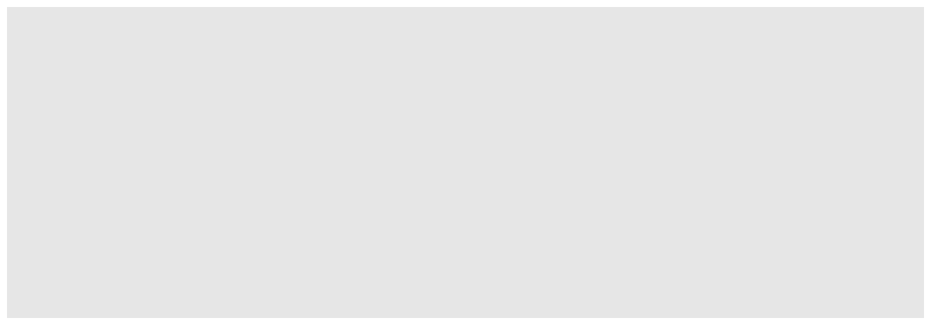

```r
ggplot(data = penguins)
```

- This creates the plotting area but doesn’t show any data yet!

## Building a Plot: Add a Layer

- Add a **layer** with points using `geom_point()`
- Specify an **aesthetic mapping** with `aes()`: which variables go where

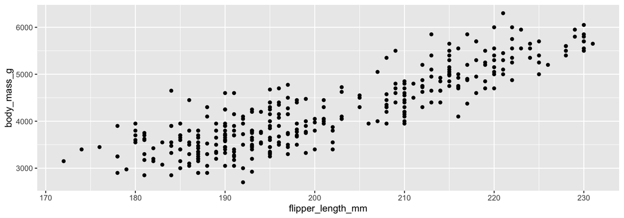

```r
ggplot(data = penguins) +
  geom_point(aes(x = flipper_length_mm, y = body_mass_g))
```

## What Do We See?

- Clear **positive relationship**: penguins with longer flippers tend to be heavier
- But could this be driven by **different species**?
- Let’s encode species information using **color**

## Adding Color by Species

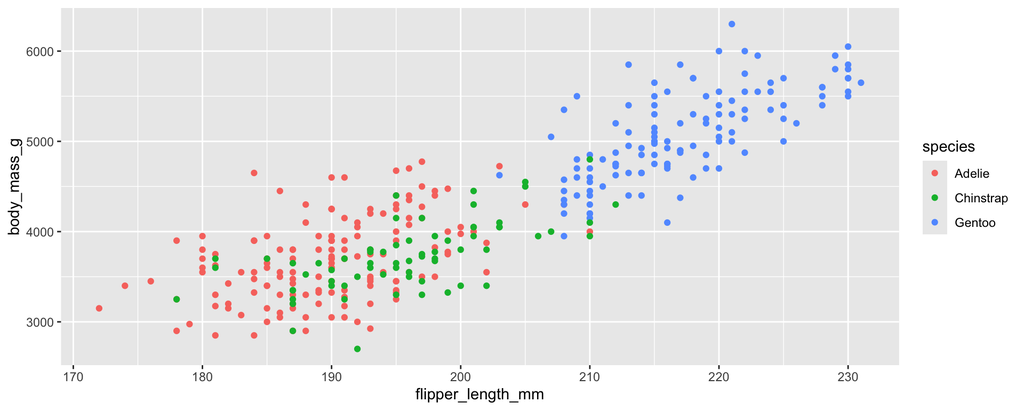

```r
ggplot(data = penguins) +
  geom_point(aes(x = flipper_length_mm, y = body_mass_g, color = species))
```

## What Do We Learn?

- Gentoo penguins (blue) are generally larger
- The positive relationship exists **within each species**
- This suggests the relationship isn’t just due to species differences

## What is a Line of Best Fit?

- A **line of best fit** is a straight line that best summarizes the relationship between two variables
- It is the line that minimizes the total distance between itself and all the data points
- Useful for:
  - Visualizing the **direction** of a relationship (positive or negative)
  - Summarizing the **overall trend** in the data
  - Making **predictions** for values we haven’t observed

## Adding a Line of Best Fit

- Add a line of best fit with `geom_smooth()`
- This is a new **layer**, not a new aesthetic

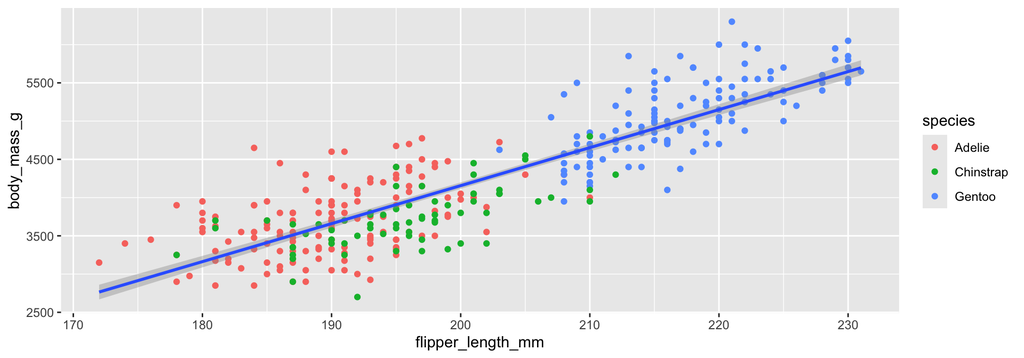

```r
ggplot(data = penguins) +
  geom_point(aes(x = flipper_length_mm, y = body_mass_g, color = species)) +
  geom_smooth(aes(x = flipper_length_mm, y = body_mass_g), method = "lm")
```

## Proper Labeling

- Good labels are **essential** for clear communication
- Use `labs()` to add titles, axis labels, and legend titles

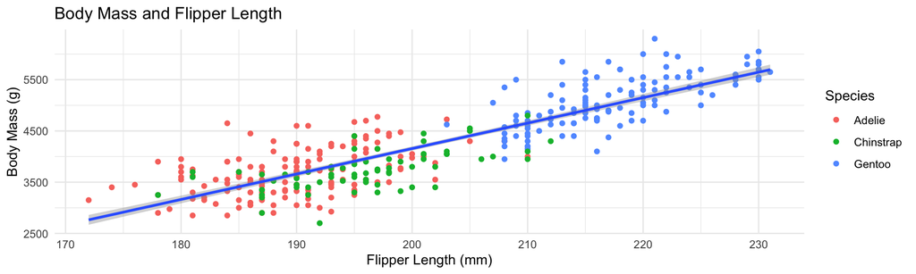

```r
ggplot(data = penguins) +
  geom_point(aes(x = flipper_length_mm, y = body_mass_g, color = species)) +
  geom_smooth(aes(x = flipper_length_mm, y = body_mass_g), method = "lm") +
  labs(
    title = "Body Mass and Flipper Length",
    x = "Flipper Length (mm)",
    y = "Body Mass (g)",
    color = "Species"
  ) +
  theme_minimal()
```

## Histograms: Visualizing Distributions

- Histograms show the distribution of a **single continuous variable**
- Use `geom_histogram()` to create them

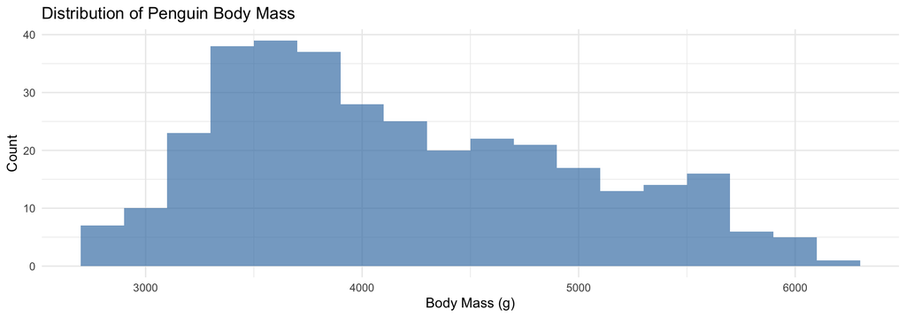

```r
ggplot(penguins) +
  geom_histogram(aes(x = body_mass_g), binwidth = 200,
                 fill = "steelblue", alpha = 0.7) +
  labs(title = "Distribution of Penguin Body Mass",
       x = "Body Mass (g)", y = "Count") +
  theme_minimal()
```

## The `binwidth` Argument

- `binwidth` controls how wide each bar is
- Smaller binwidths = more bars = more detail

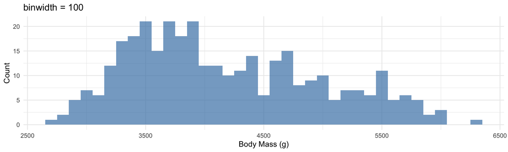

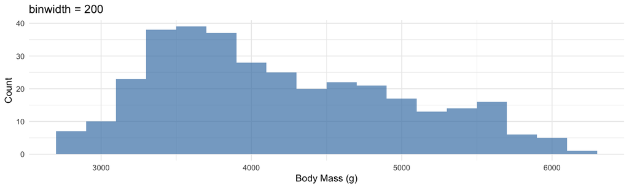

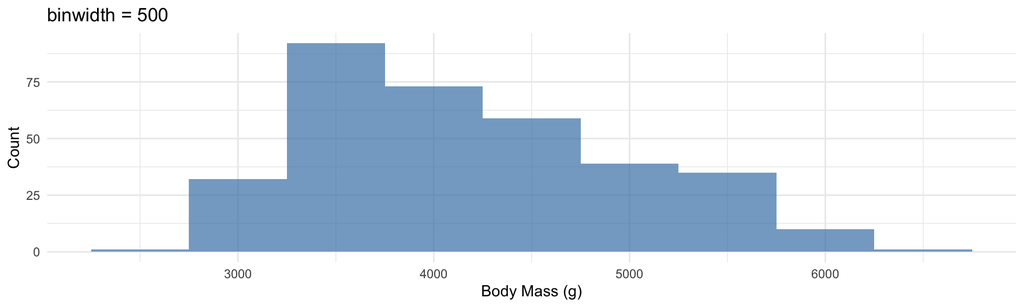

## Quick Reference: Key ggplot2 Functions

| Function | What it does |
| --- | --- |
| `ggplot(data)` | Initialize plot with data |
| `aes(x, y, color, ...)` | Map variables to aesthetics |
| `geom_point()` | Add points (scatterplot) |
| `geom_smooth()` | Add trend line |
| `geom_histogram()` | Add histogram |
| `geom_col()` | Add bar chart |
| `labs()` | Add labels and titles |
| `theme_minimal()` | Clean, minimal theme |

## Building Intuition

The layered approach of ggplot2 mirrors how we think about data analysis:

1. Start with the **data**
2. Add **visual representations** (geoms)
3. Refine with **labels and formatting**

Experiment with different geometries, aesthetics, and layers to find the visualization that best tells your data’s story!

## Practice: Visualization Exercises

**🖥️ Your turn!**

Using the `penguins` data, try to create each of the following visualizations. Give each one a try before clicking to reveal the answer!

## Visualization Practice 1

**Create a histogram of penguin flipper length (`flipper_length_mm`).**

- *Hint:* Use `geom_histogram()` with `aes(x = ...)`

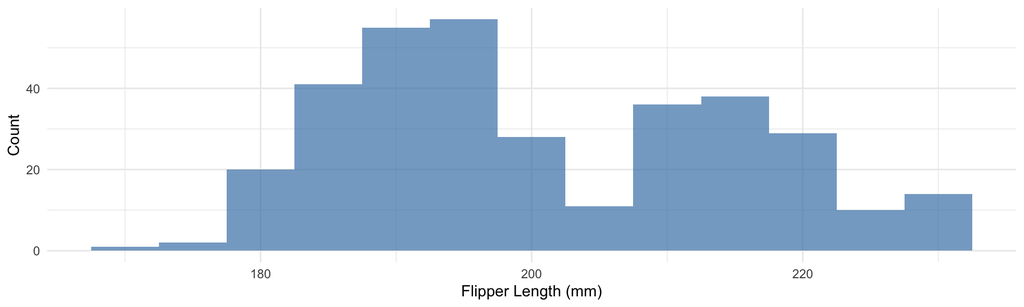

```r
ggplot(penguins) +
  geom_histogram(aes(x = flipper_length_mm), binwidth = 5,
                 fill = "steelblue", alpha = 0.7) +
  labs(x = "Flipper Length (mm)", y = "Count") +
  theme_minimal()
```

## Visualization Practice 2

**Create a scatterplot of bill length (`bill_length_mm`) vs. bill depth (`bill_depth_mm`).**

- *Hint:* Use `geom_point()` with `aes(x = ..., y = ...)`

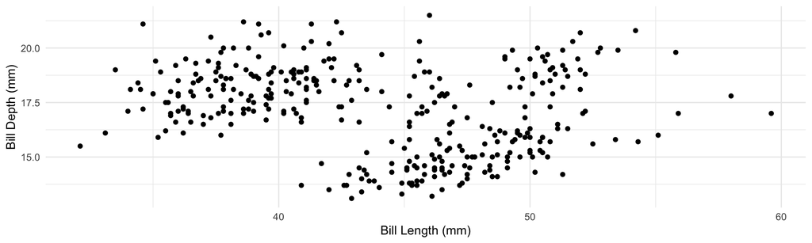

```r
ggplot(penguins) +
  geom_point(aes(x = bill_length_mm, y = bill_depth_mm)) +
  labs(x = "Bill Length (mm)", y = "Bill Depth (mm)") +
  theme_minimal()
```

## Visualization Practice 3

**Modify the previous scatterplot to color the points by species.**

- *Hint:* Add `color = species` inside `aes()`

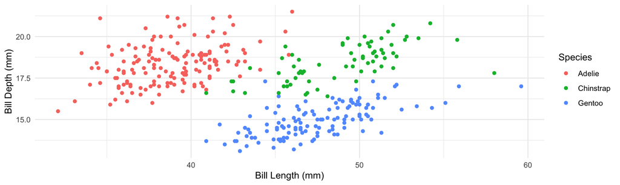

```r
ggplot(penguins) +
  geom_point(aes(x = bill_length_mm, y = bill_depth_mm, color = species)) +
  labs(x = "Bill Length (mm)", y = "Bill Depth (mm)", color = "Species") +
  theme_minimal()
```

## Visualization Practice 4

**Add a line of best fit to the scatterplot of flipper length vs. body mass, and add proper axis labels and a title.**

- *Hint:* Combine `geom_point()`, `geom_smooth(method = "lm")`, and `labs()`

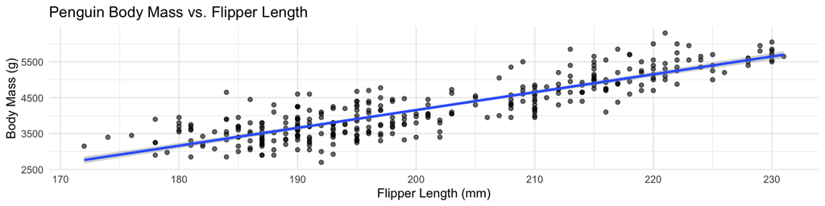

```r
ggplot(penguins) +
  geom_point(aes(x = flipper_length_mm, y = body_mass_g), alpha = 0.6) +
  geom_smooth(aes(x = flipper_length_mm, y = body_mass_g), method = "lm") +
  labs(title = "Penguin Body Mass vs. Flipper Length",
       x = "Flipper Length (mm)", y = "Body Mass (g)") +
  theme_minimal()
```

EC325 | Unit 2 | Good Data Practices